# Find best timings to upsell additional amounts or customers to upsell extensions

## Preparing data for analysis

First i will create 14 separate columns for each date of additional extensions,(14 because - one of clients nad 14 add. amounts). Instead of creating separate table for each month i divided by number of extensions for specifc loan

##Most additional amount was sold ?

```r
# x <-x %>%  replace(is.na(.), 0)
# cor(x)
```

The best time for selling the first additional extension would be second half ot the year, mostly the last 4 month, at this time also amount could be high - so definetly November and Decemebr

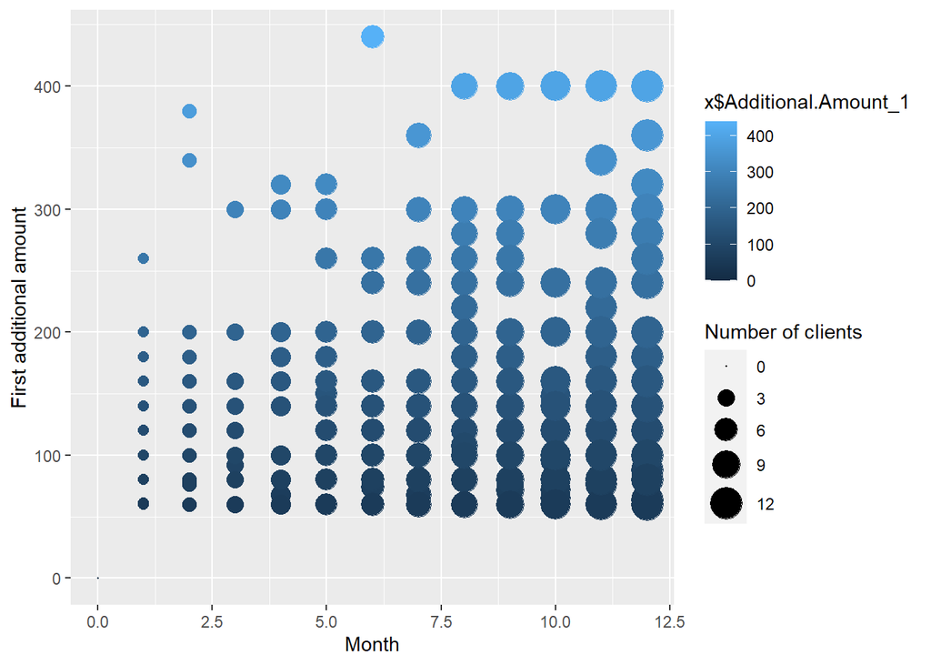

```r
x %>%
  arrange(desc(x$Additional.Amount_1)) %>%
  #mutate(country = factor(country, country)) %>%
  ggplot(aes(y=x$Additional.Amount_1, x=x$created_1, size = x$created_1, color=x$Additional.Amount_1)) +
    geom_point(alpha = 1.5 ) +
    scale_size(range = c(.2, 8), name="Number of clients ") +
    ylab("First additional amount") +
    xlab("Month")
```

The next analysis confirm that in case of second aggrement the best motnth for upselling is December November with Septmeber

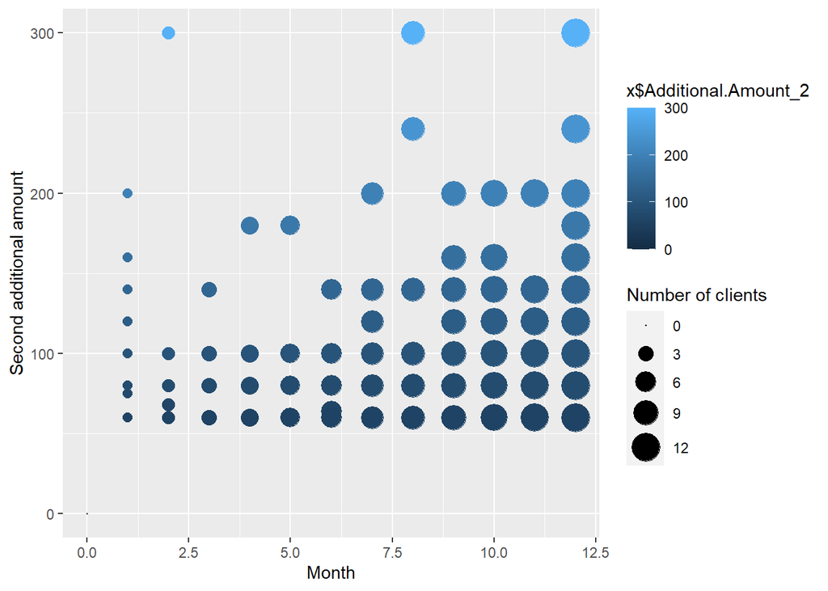

```r
x %>%
  arrange(desc(x$Additional.Amount_2)) %>%
  #mutate(country = factor(country, country)) %>%
  ggplot(aes(y=x$Additional.Amount_2, x=x$created_2, size = x$created_2,    color=x$Additional.Amount_2)) +
    geom_point(alpha = 1.5 ) +
    scale_size(range = c(.2, 8), name="Number of clients ") +
    ylab("Second additional amount") +
    xlab("Month")
```

And the the third additional amount slightly flatten, but underline that 4Q of the year is the best for selling additonal amount

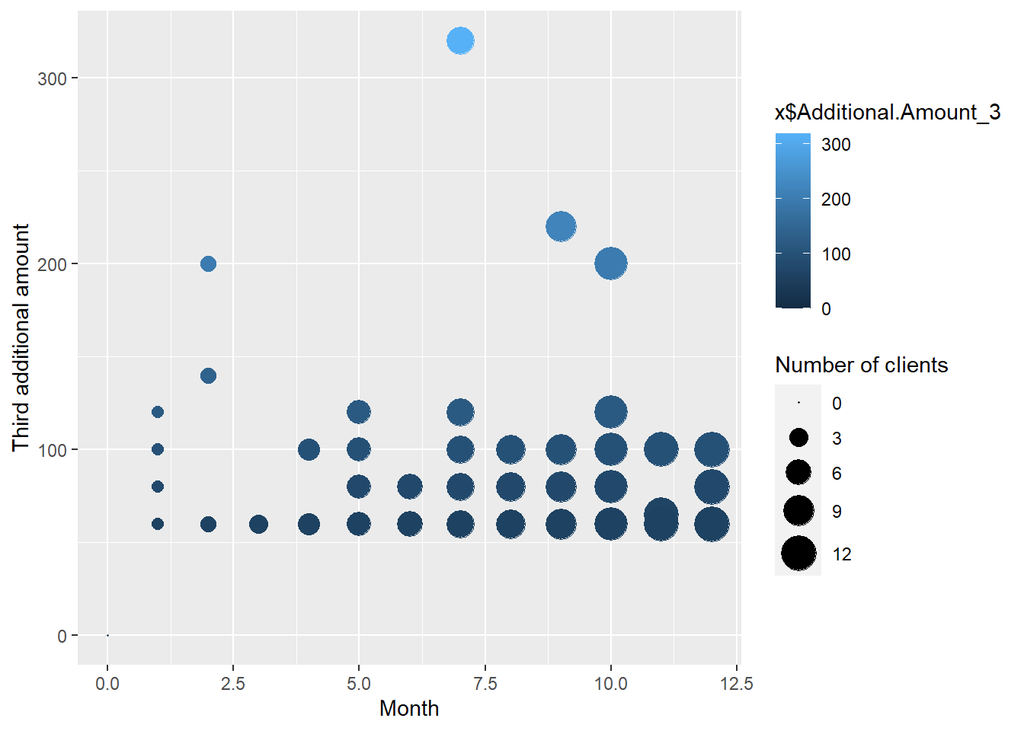

```r
x %>%
  arrange(desc(x$Additional.Amount_3)) %>%
  #mutate(country = factor(country, country)) %>%
  ggplot(aes(y=x$Additional.Amount_3, x=x$created_3, size = x$created_3,    color=x$Additional.Amount_3)) +
    geom_point(alpha = 1.5 ) +
    scale_size(range = c(.2, 8), name="Number of clients ") +
    ylab("Third additional amount") +
    xlab("Month")
```

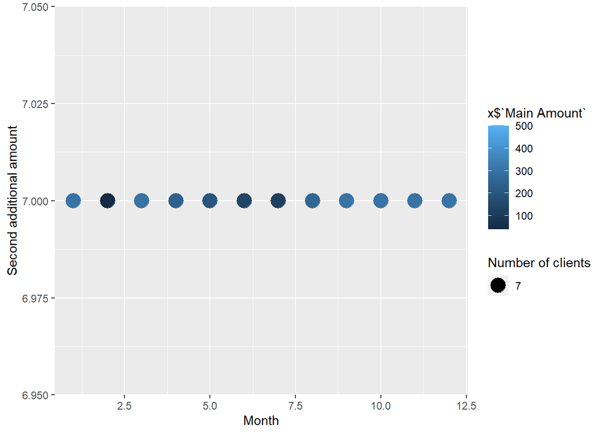

```r
x %>%
  arrange(desc(x$`Signed Date`)) %>%
  #mutate(country = factor(country, country)) %>%
  ggplot(aes(y=x$`Client Number`, x=x$`Signed Date`, size = x$`Client Number`,    color=x$`Main Amount`)) +
    geom_point(alpha = 1.5 ) +
    scale_size(range = c(.2, 8), name="Number of clients ") +
    ylab("Second additional amount") +
    xlab("Month")
```

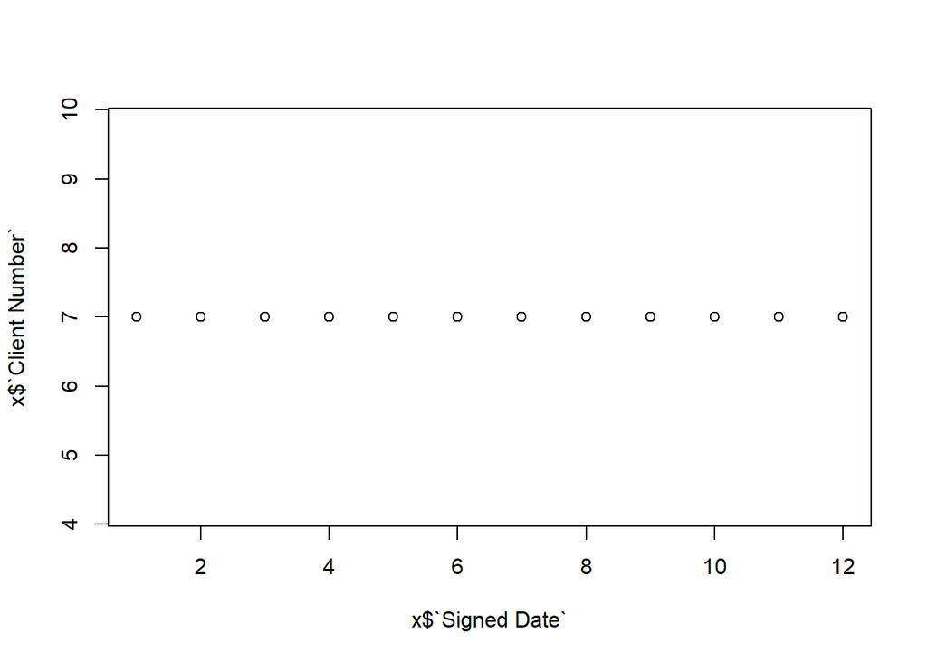

```r
plot(x$`Signed Date`,x$`Client Number` )
```

[figure not shown]

```r
x1 <- aggregate(x$`Signed Date`, by=list(Category= x$`Client Number`), FUN=sum)
plot( x1$x, x1$Category)
```

```r
timing <- merge(x = x1, y = test_2, by = "loan.number", all = TRUE)
```

```
## Error in fix.by(by.x, x): 'by' must specify a uniquely valid column
```